# Simulation study: CLT

Alice

12/5/2019

### purpose of this study

In this simulation study, we are going to compare the sampling distribution of the mean generated by simulation to the sampling distribution implied by the central limit theorem. We will compare the distributions graphically in QQ-plots.

### Underline distribution

The underlying distribution will be the Skew-Normal distribution. The Skew-Normal distribution has three parameters: location, scale, and slant. When the slant parameter is 0, the distribution reverts to the normal distribution. As the slant parameter increases, the distribution becomes increasingly skewed.

### Experiment design

We will set the location and scale to 0 and 1, respectively, for all simulation settings. This will be a 4 × 4 factorial experiment. The first factor will be the sample size, with N = 5, 10, 20, and 40. The second factor will be the degree of skewness in the underlying distribution. In this simulation, slant will be set to 0, 2, 10,100.

The output of each combination of factors will be a QQ-plot. Generate a sampling distribution of 5000 draws from both the CLT approximation and the simulation approximation. When analyzing data, the parameters for the mean and variance (in the case of the CLT shortcut) or the parameters for the distribution (in the case of MLE, MM, etc) are replaced with sample estimates. (This is often called the plug-in approach.) For the purposes of this simulation, treat the mean and variance as known values and use the actual population parameters and the population mean and variance instead of sample estimates.

```r
require(magrittr)
require(sn)
```

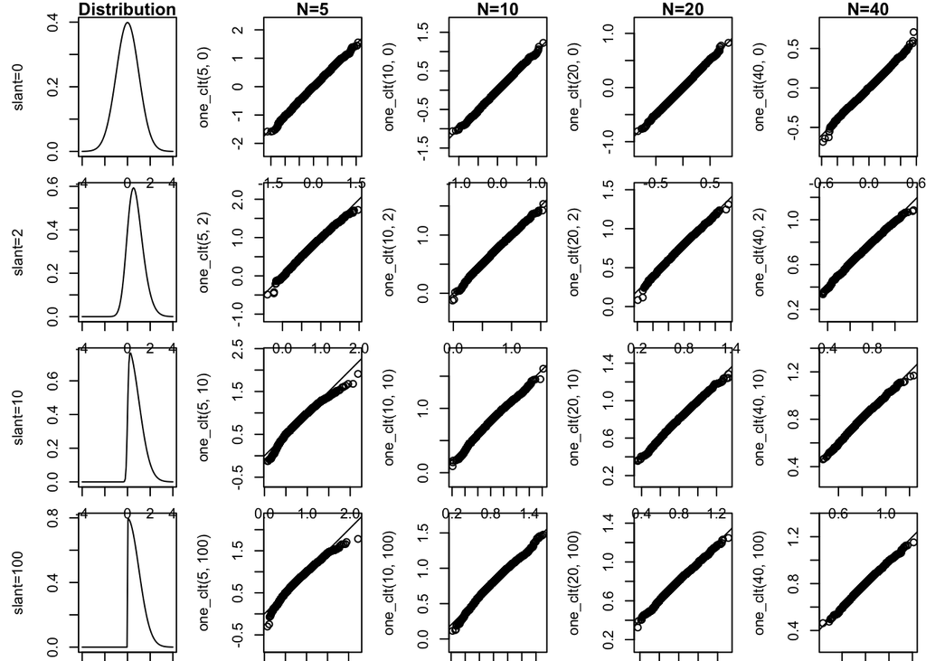

```r
# Parameters that do not change
R <- 5000; location <- 0; scale <- 1
# Parameters that change
one_sim <-function(N,slant){
  # Quantites to calculate/generate
  delta <- slant/(sqrt(1+slant^2))
  pop_mean <- location+scale*delta*(sqrt(2/pi))
  pop_sd <- sqrt(scale^2*(1-(2*delta^2)/pi))
  random.skew <- array(rsn(R*N, xi = location, omega = scale, alpha = slant), dim = c(R,N))
  sample_dist_sim <- apply(random.skew, 1, mean)
  sample_dist_sim
}
one_clt <-function(N,slant){
  delta <- slant/(sqrt(1+slant^2))
  pop_mean <- location+scale*delta*(sqrt(2/pi))
  pop_sd <- sqrt(scale^2*(1-(2*delta^2)/pi))
  Z <- rnorm(R)
  sample_dist_clt <- Z*(pop_sd/sqrt(N)) + pop_mean
}
# QQ plot
par(mfrow=c(4,5))
par(mar=c(0.5, 4.5, 1, 0.5))
plot(seq(-4, 4, length=100),dsn(seq(-4, 4, length=100),0,1,0),type='l',main='Distribution',ylab='slant=0')
qqplot(one_sim(5,0), one_clt(5,0), asp = 1,main='N=5')
abline(0,1)
qqplot(one_sim(10,0), one_clt(10,0), asp = 1,main='N=10')
abline(0,1)
qqplot(one_sim(20,0), one_clt(20,0), asp = 1,main='N=20')
abline(0,1)
qqplot(one_sim(40,0), one_clt(40,0), asp = 1,main='N=40')
abline(0,1)
plot(seq(-4, 4, length=100),dsn(seq(-4, 4, length=100),0,1,2),type='l',ylab='slant=2')
qqplot(one_sim(5,2), one_clt(5,2), asp = 1)
abline(0,1)
qqplot(one_sim(10,2), one_clt(10,2), asp = 1)
abline(0,1)
qqplot(one_sim(20,2), one_clt(20,2), asp = 1)
abline(0,1)
qqplot(one_sim(40,2), one_clt(40,2), asp = 1)
abline(0,1)
plot(seq(-4, 4, length=100),dsn(seq(-4, 4, length=100),0,1,10),type='l',ylab='slant=10')
qqplot(one_sim(5,10), one_clt(5,10), asp = 1)
abline(0,1)
qqplot(one_sim(10,10), one_clt(10,10), asp = 1)
abline(0,1)
qqplot(one_sim(20,10), one_clt(20,10), asp = 1)
abline(0,1)
qqplot(one_sim(40,10), one_clt(40,10), asp = 1)
abline(0,1)
plot(seq(-4, 4, length=100),dsn(seq(-4, 4, length=100),0,1,100),type='l',ylab='slant=100')
qqplot(one_sim(5,100), one_clt(5,100), asp = 1)
abline(0,1)
qqplot(one_sim(10,100), one_clt(10,100), asp = 1)
abline(0,1)
qqplot(one_sim(20,100), one_clt(20,100), asp = 1)
abline(0,1)
qqplot(one_sim(40,100), one_clt(40,100), asp = 1)
abline(0,1)
```